# **Práctica Optimización**

Se pide resolver el siguiente problema de optimización:

Minimiza 𝑓(𝑥) = 3𝑥1 + 0.000001𝑥1^3 + 2𝑥2 + 0.000002/3𝑥2^3

sujeto a:

𝑔1(𝑥) ≡ −𝑥4 + 𝑥3 − 0.55 ≤ 0

𝑔2(𝑥) ≡ −𝑥3 + 𝑥4 − 0.55 ≤ 0

ℎ1(𝑥) ≡ 1000 sin (−𝑥3 − 0.25) + 1000 sin (−𝑥4 − 0.25) + 894.8 −𝑥1 = 0

ℎ2(𝑥) ≡ 1000 sin (𝑥3 − 0.25) + 1000 sin (𝑥3 − 𝑥4 − 0.25) + 894.8 − 𝑥2 = 0

ℎ3(𝑥) ≡ 1000 sin (𝑥4 − 0.25) + 1000 sin (𝑥4 − 𝑥3 − 0.25) + 1294.8 = 0

donde:

0 ≤ 𝑥1 ≤ 1200

0 ≤ 𝑥2 ≤ 1200

−0.55 ≤ 𝑥3 ≤ 0.55

−0.55 ≤ 𝑥4 ≤ 0.55

**Se deben subir los ficheros csv a la carpeta "content". En caso de ejecutar el código en local, se debe cambiar la ubicación "/content/fichero.csv" por "content/fichero.csv". Al ejecutar el código se generarán nuevos .csv**

### Descarga de las librerías necesarias

```python
!pip install inspyred
!pip install optuna
```

### Importar librerías

```python
import inspyred
import optuna
import numpy as np
import random
import math
import time
from scipy.stats import wilcoxon
import pandas as pd
import csv
```

### Definición funciones objetivo y constraints

Constraints

```python
def g1_constraint(x4, x3):
  return -x4 + x3 - 0.55

def g2_constraint(x4, x3):
  return x4 - x3 -0.55

def h1_constraint(x4,x3,x1):
  return 1000*np.sin(-x3-0.25) + 1000*np.sin(-x4-0.25) + 894.8-x1

def h2_constraint(x4,x3,x2):
  return 1000*np.sin(x3-0.25) + 1000*np.sin(x3-x4-0.25) + 894.8-x2

def h3_constraint(x4,x3):
  return 1000*np.sin(x4-0.25) + 1000*np.sin(x4-x3-0.25) + 1294.8
```

Función a optimizar

```python
def function_to_minimize(x1, x2):
  return 3*x1 + 0.000001*(x1**3) + 2*x2 + (0.000002/(3*(x2**3)))
```

Generador de números

```python
# Define la función generador
def generate(random, args):
  x1 = random.uniform(0,1200)
  x2 = random.uniform(1e-15, 1200)
  x3 = random.uniform(-0.55, 0.55)
  x4 = random.uniform(-0.55, 0.55)
  return [x1, x2, x3, x4]
```

**Funciones de penalización:**

function_with_dynamic_penalization: se aumentan los coeficientes que penalizan en función del número de iteraciones que lleva el modelo

function_with_objective_penalization: se aumentan los coeficientes que penalizan en función de los contraints que no se cumplen

function: los coeficientes de penalización son siempre los mismos

*Para este trabajo se ha utilizado "function_with_dynamic_penalization", pues es la que mejor ha funcionado*

```python
def function_with_dynamic_penalization(candidates, args):
    #print(args['_ec'].num_generations)
    global R1, R2, R3, R4, R5
    global success_rate
    fitness = []
    #print(R1)
    if args['_ec'].num_generations%25 == 0:
      R1 *= 1.5
      R2 *= 1.5
      R3 *= 1.5
      R4 *= 1.5
      R5 *= 1.5

    for cs in candidates:
        #print(f'R1: {R1}, R2: {R2}, R3: {R3}, R4: {R4}, R5: {R5}')
        fit = function_to_minimize(cs[0], cs[1]) + R1*max(g1_constraint(cs[3], cs[2]), 0) + R2*max(g2_constraint(cs[3], cs[2]), 0) + R3*abs(h1_constraint(cs[3], cs[2], cs[0])) + R4*abs(h2_constraint(cs[3], cs[2], cs[1])) + R5*abs(h3_constraint(cs[3], cs[2]))

        #Dev print ---> Muestra por pantalla si se encuentra alguna solución que cumpla todos los constraints
        '''if function_to_minimize(cs[0], cs[1]) == fit:
          print(f'Cumple las condiciones con x1={cs[0]}, x2={cs[1]}, x3={cs[2]}, x4={cs[3]} y con fitness={fit}')
          success_rate.append(1)
        else:
          success_rate.append(0)'''
        fitness.append(fit)
    return fitness
```

```python
#Prueba de función que penaliza en función de aquellas condiciones que no se cumplen. Funciona peor que la otra función

def function_with_objective_penalization(candidates, args):
    #print(args['_ec'].num_generations)
    global R1, R2, R3, R4, R5
    global success_rate
    fitness = []

    initial_R1, initial_R2, initial_R3, initial_R4, initial_R5 = R1, R2, R3, R4, R5

    #print(R1)
    for cs in candidates:
        first_condition = R1*max(g1_constraint(cs[3], cs[2]), 0)
        second_condition = R2*max(g2_constraint(cs[3], cs[2]), 0)
        third_condition = R3*abs(h1_constraint(cs[3], cs[2], cs[0]))
        fourth_condition = R4*abs(h2_constraint(cs[3], cs[2], cs[1]))
        fifth_condition = R5*abs(h3_constraint(cs[3], cs[2]))
        #print(f'R1: {R1}, R2: {R2}, R3: {R3}, R4: {R4}, R5: {R5}')
        fit = function_to_minimize(cs[0], cs[1]) + first_condition + second_condition + third_condition + fourth_condition + fifth_condition

        if first_condition > 0:
            R1 = initial_R1 + 1.5
        elif second_condition > 0:
            R2 = initial_R2 + 1.5
        elif third_condition != 0:
            R3 = initial_R3 + 1.5
        elif fourth_condition != 0:
            R4 = initial_R4 + 1.5
        elif fifth_condition != 0:
            R5 = initial_R5 + 1.5

        fitness.append(fit)
    return fitness
```

```python
def function(candidates, args):
    #print(args['_ec'].num_generations)
    global R1, R2, R3, R4, R5

    fitness = []
    global success_rate
    #print(R1)

    for cs in candidates:
        #print(f'R1: {R1}, R2: {R2}, R3: {R3}, R4: {R4}, R5: {R5}')
        fit = function_to_minimize(cs[0], cs[1]) + R1*max(g1_constraint(cs[3], cs[2]), 0) + R2*max(g2_constraint(cs[3], cs[2]), 0) + R3*abs(h1_constraint(cs[3], cs[2], cs[0])) + R4*abs(h2_constraint(cs[3], cs[2], cs[1])) + R5*abs(h3_constraint(cs[3], cs[2]))

        #Dev print ---> Muestra por pantalla si se encuentra alguna solución que cumpla todos los constraints
        '''if function_to_minimize(cs[0], cs[1]) == fit:
          print(f'Cumple las condiciones con x1={cs[0]}, x2={cs[1]}, x3={cs[2]}, x4={cs[3]} y con fitness={fit}')
          success_rate.append(1)
        else:
          success_rate.append(0)'''
        fitness.append(fit)
    return fitness
```

### Modelo base

Este modelo es similar al ejemplo

```
Best Solution: [556.1639357891985, 1161.6833105971914, 0.20877778154099375, -0.35441686097232517], Objective Value: 4165.432693881806
```

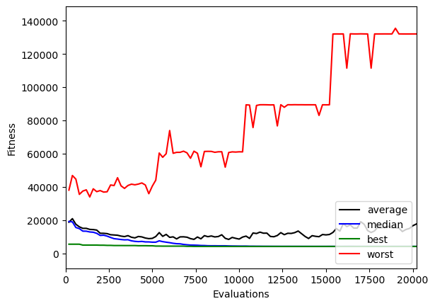

```python
rng = random.Random()
rng.seed(123456789)

# Crea el algoritmo evolutivo
ea = inspyred.ec.GA(rng)
ea.selector = inspyred.ec.selectors.tournament_selection
ea.variator = [inspyred.ec.variators.simulated_binary_crossover,
               inspyred.ec.variators.gaussian_mutation]
ea.replacer = inspyred.ec.replacers.generational_replacement
ea.terminator = inspyred.ec.terminators.generation_termination
ea.observer = inspyred.ec.observers.plot_observer

R1 = 5
R2 = 5
R3 = 5
R4 = 5
R5 = 5

#Descomentar esto si se utiliza el print en las funciones evaluadoras
#success_rate = []

# Ejecución del modelo
final_pop = ea.evolve(generator=generate,
                      evaluator=function_with_dynamic_penalization,
                      pop_size=200,
                      maximize=False,
                      bounder=inspyred.ec.Bounder([0, 1e-16, -0.55, -0.55], [1200, 1200, 0.55, 0.55]),
                      tournament_size=2,
                      max_generations=100,
                      crossover_rate=1,
                      mutation_rate=0.1,
                      num_elites=1)

# Ordena y muestra al mejor individuo
final_pop.sort(key=lambda x: x.fitness)
best = final_pop[0]
print(f'Best Solution: {str(best.candidate)}, Objective Value: {best.fitness}')
```

```python
function_to_minimize(best.candidate[0], best.candidate[1])
```

```
4163.890124756178
```

Se puede apreciar que se ajusta relativamente bien a los constraints, pues entre el valor real y el valor con los constraints hay poca diferencia, de aproximadamente 1.5426

### Optuna

El objetivo es encontrar gracias a optuna una configuración óptima de los hiperparámetros. Debido a cómo funciona la librería por debajo, hay un factor aleatorio

```python
def objective(trial):

    global R1, R2, R3, R4, R5
    # Espacio de búsqueda de hiperparámetros
    pop_size = trial.suggest_int('pop_size', 50, 200)
    crossover_rate = trial.suggest_uniform('crossover_rate', 0.5, 1.0)
    mutation_rate = trial.suggest_uniform('mutation_rate', 0.01, 0.2)

    # Configuración del algoritmo
    rng = random.Random()
    rng.seed(123456789)

    R1 = 5
    R2 = 5
    R3 = 5
    R4 = 5
    R5 = 5

    ea = inspyred.ec.GA(rng)
    ea.selector = inspyred.ec.selectors.tournament_selection
    ea.variator = [inspyred.ec.variators.simulated_binary_crossover,
                   inspyred.ec.variators.gaussian_mutation]
    ea.replacer = inspyred.ec.replacers.generational_replacement
    ea.terminator = inspyred.ec.terminators.generation_termination

    # Ejecución del modelo
    final_pop = ea.evolve(generator=generate,
                          evaluator=function_with_dynamic_penalization,
                          pop_size=pop_size,
                          maximize=False,
                          bounder=inspyred.ec.Bounder([0, 1e-16, -0.55, -0.55], [1200, 1200, 0.55, 0.55]),
                          tournament_size=2,
                          max_generations=100,
                          crossover_rate=crossover_rate,
                          mutation_rate=mutation_rate,
                          num_elites=1)


    final_pop.sort(key=lambda x: x.fitness)
    best = final_pop[0]

    return best.fitness

# Optimizar en función de lo que se quiera (en este caso, minimizar)
study = optuna.create_study(direction='minimize')
study.optimize(objective, n_trials=50)

# Mostrar los mejores hiperparámetros y su valor
best_params = study.best_params
best_value = study.best_value
print(f'Best Parameters: {best_params}, Best Objective Value: {best_value}')
```

```
[I 2023-12-03 21:45:32,900] A new study created in memory with name: no-name-99ec7642-37a6-4357-99e8-213f5f19be57
[I 2023-12-03 21:45:33,501] Trial 0 finished with value: 4865.553855692064 and parameters: {'pop_size': 169, 'crossover_rate': 0.7937272284467967, 'mutation_rate': 0.1319610266809045}. Best is trial 0 with value: 4865.553855692064.
[I 2023-12-03 21:45:33,804] Trial 1 finished with value: 4239.7644664352765 and parameters: {'pop_size': 110, 'crossover_rate': 0.834118820522814, 'mutation_rate': 0.13773411127794497}. Best is trial 1 with value: 4239.7644664352765.
[I 2023-12-03 21:45:34,198] Trial 2 finished with value: 5155.811861465586 and parameters: {'pop_size': 148, 'crossover_rate': 0.6899023883621015, 'mutation_rate': 0.03541787868362106}. Best is trial 1 with value: 4239.7644664352765.
[I 2023-12-03 21:45:34,386] Trial 3 finished with value: 5517.902531362737 and parameters: {'pop_size': 68, 'crossover_rate': 0.8359827692798473, 'mutation_rate': 0.14673242357289398}. Best is trial 1 with value: 4239.7644664352765.
[I 2023-12-03 21:45:34,776] Trial 4 finished with value: 5517.902531362737 and parameters: {'pop_size': 163, 'crossover_rate': 0.5390620456886517, 'mutation_rate': 0.16478721964546517}. Best is trial 1 with value: 4239.7644664352765.
[I 2023-12-03 21:45:35,301] Trial 5 finished with value: 5517.902531362737 and parameters: {'pop_size': 164, 'crossover_rate': 0.8320022325016792, 'mutation_rate': 0.076828903776712}. Best is trial 1 with value: 4239.7644664352765.
[I 2023-12-03 21:45:35,454] Trial 6 finished with value: 5517.902531362737 and parameters: {'pop_size': 52, 'crossover_rate': 0.7891760413894695, 'mutation_rate': 0.07566987466309792}. Best is trial 1 with value: 4239.7644664352765.
[I 2023-12-03 21:45:35,894] Trial 7 finished with value: 4627.603954080896 and parameters: {'pop_size': 152, 'crossover_rate': 0.7580127422629458, 'mutation_rate': 0.07001234563431302}. Best is trial 1 with value: 4239.7644664352765.
[I 2023-12-03 21:45:36,183] Trial 8 finished with value: 5517.902531362737 and parameters: {'pop_size': 102, 'crossover_rate': 0.5592911478632756, 'mutation_rate': 0.05560886502909877}. Best is trial 1 with value: 4239.7644664352765.
[I 2023-12-03 21:45:36,746] Trial 9 finished with value: 4681.773816525464 and parameters: {'pop_size': 175, 'crossover_rate': 0.8563871139946313, 'mutation_rate': 0.03841762764783737}. Best is trial 1 with value: 4239.7644664352765.
[I 2023-12-03 21:45:37,091] Trial 10 finished with value: 4669.523145923559 and parameters: {'pop_size': 107, 'crossover_rate': 0.9651123895510154, 'mutation_rate': 0.19440685479319403}. Best is trial 1 with value: 4239.7644664352765.
[I 2023-12-03 21:45:37,461] Trial 11 finished with value: 4949.192801310753 and parameters: {'pop_size': 130, 'crossover_rate': 0.7041734905913641, 'mutation_rate': 0.1122836496693125}. Best is trial 1 with value: 4239.7644664352765.
[I 2023-12-03 21:45:38,042] Trial 12 finished with value: 4297.796720588807 and parameters: {'pop_size': 198, 'crossover_rate': 0.9280297081059456, 'mutation_rate': 0.013880357422265371}. Best is trial 1 with value: 4239.7644664352765.
[I 2023-12-03 21:45:38,591] Trial 13 finished with value: 4404.149373881898 and parameters: {'pop_size': 193, 'crossover_rate': 0.9670462142298955, 'mutation_rate': 0.019986000208617877}. Best is trial 1 with value: 4239.7644664352765.
[I 2023-12-03 21:45:38,858] Trial 14 finished with value: 5022.3681669336775 and parameters: {'pop_size': 90, 'crossover_rate': 0.9044930054484209, 'mutation_rate': 0.01041626737278935}. Best is trial 1 with value: 4239.7644664352765.
[I 2023-12-03 21:45:39,234] Trial 15 finished with value: 4470.395959737032 and parameters: {'pop_size': 126, 'crossover_rate': 0.9119151935931176, 'mutation_rate': 0.09929256393544707}. Best is trial 1 with value: 4239.7644664352765.
[I 2023-12-03 21:45:39,881] Trial 16 finished with value: 4739.059203228433 and parameters: {'pop_size': 200, 'crossover_rate': 0.9956576735778389, 'mutation_rate': 0.10230579484561189}. Best is trial 1 with value: 4239.7644664352765.
[I 2023-12-03 21:45:40,134] Trial 17 finished with value: 4354.903866487904 and parameters: {'pop_size': 81, 'crossover_rate': 0.9075267508390988, 'mutation_rate': 0.12397401356291625}. Best is trial 1 with value: 4239.7644664352765.
[I 2023-12-03 21:45:40,469] Trial 18 finished with value: 5103.39653212194 and parameters: {'pop_size': 112, 'crossover_rate': 0.8803818103296827, 'mutation_rate': 0.09150162582056291}. Best is trial 1 with value: 4239.7644664352765.
[I 2023-12-03 21:45:40,863] Trial 19 finished with value: 4443.617550398472 and parameters: {'pop_size': 139, 'crossover_rate': 0.9404888617870126, 'mutation_rate': 0.053747222255843184}. Best is trial 1 with value: 4239.7644664352765.
[I 2023-12-03 21:45:41,504] Trial 20 finished with value: 4904.2340080447075 and parameters: {'pop_size': 186, 'crossover_rate': 0.854913625245878, 'mutation_rate': 0.15100772844833002}. Best is trial 1 with value: 4239.7644664352765.
```

[output cut: 29 more lines]

```
Best Parameters: {'pop_size': 121, 'crossover_rate': 0.8757589019862796, 'mutation_rate': 0.14274991785931956}, Best Objective Value: 4127.09244869541
```

Construyo ahora uno de los mejores modelos que obtuve ejecutando la celda de código anterior

```
Best Solution: [685.1050952988347, 1020.5594264051272, 0.11519947587759077, -0.39798023669301336], Objective Value: 4418.002880602814
```

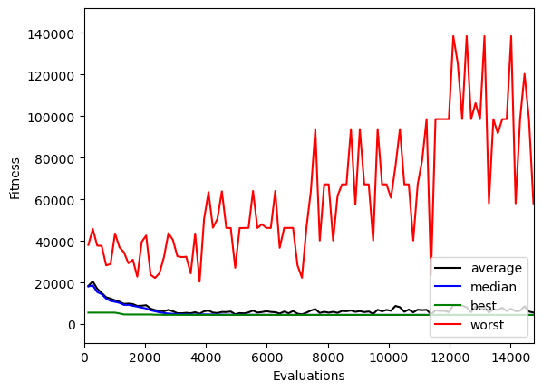

```python
rng = random.Random()
rng.seed(123456789)

ea = inspyred.ec.GA(rng)
ea.selector = inspyred.ec.selectors.tournament_selection
ea.variator = [inspyred.ec.variators.simulated_binary_crossover,
               inspyred.ec.variators.gaussian_mutation]
ea.replacer = inspyred.ec.replacers.generational_replacement
ea.terminator = inspyred.ec.terminators.generation_termination
ea.observer = inspyred.ec.observers.plot_observer

R1 = 5
R2 = 5
R3 = 5
R4 = 5
R5 = 5

#Descomentar esto si se utiliza el print en las funciones evaluadoras
#success_rate = []

# Configuración del modelo con los valores de Optuna
final_pop = ea.evolve(generator=generate,
                      evaluator=function_with_dynamic_penalization,
                      pop_size=146,
                      maximize=False,
                      bounder=inspyred.ec.Bounder([0, 1e-16, -0.55, -0.55], [1200, 1200, 0.55, 0.55]),
                      tournament_size=2,
                      max_generations=100,
                      crossover_rate=0.9624544382587448,
                      mutation_rate=0.03141668139619255,
                      num_elites=1)

final_pop.sort(key=lambda x: x.fitness)
best = final_pop[0]
print(f'Best Solution: {str(best.candidate)}, Objective Value: {best.fitness}')
```

```python
function_to_minimize(best.candidate[0], best.candidate[1])
```

```
4418.001226430226
```

### Optuna cambiando paramétros clave del modelo

El objetivo es cambiar ahora también el selector, el variator y el replacer del modelo, y que optuna decida qué valores son los que mejor parecen funcionar

```python
def objective(trial):

    global R1, R2, R3, R4, R5
    # Espacio de búsqueda de hiperparámetros numéricos
    pop_size = trial.suggest_int('pop_size', 100, 300)
    crossover_rate = trial.suggest_uniform('crossover_rate', 0.5, 1.0)
    mutation_rate = trial.suggest_uniform('mutation_rate', 0.01, 0.2)

    # Elección del selector, variator y replacer con Optuna
    selector = trial.suggest_categorical('selector', ['tournament_selection', 'rank_selection'])
    variator = trial.suggest_categorical('variator', ['simulated_binary_crossover', 'arithmetic_crossover', 'blend_crossover', 'laplace_crossover'])
    replacer = trial.suggest_categorical('replacer', ['generational_replacement', 'steady_state_replacement', 'crowding_replacement'])

    # Configurar el algoritmo
    rng = random.Random()
    rng.seed(123456789)

    ea = inspyred.ec.GA(rng)
    ea.selector = getattr(inspyred.ec.selectors, selector)
    ea.variator = [getattr(inspyred.ec.variators, variator),
                   inspyred.ec.variators.gaussian_mutation]
    ea.replacer =  getattr(inspyred.ec.replacers, replacer)
    ea.terminator = inspyred.ec.terminators.generation_termination

    R1 = 3
    R2 = 3
    R3 = 7
    R4 = 7
    R5 = 7

    # Ejecutar el algoritmo
    final_pop = ea.evolve(generator=generate,
                          evaluator=function_with_dynamic_penalization,
                          pop_size=pop_size,
                          maximize=False,
                          bounder=inspyred.ec.Bounder([0, 1e-16, -0.55, -0.55], [1200, 1200, 0.55, 0.55]),
                          tournament_size=2,
                          max_generations=100,
                          crossover_rate=crossover_rate,
                          mutation_rate=mutation_rate,
                          num_elites=1)

    # Obtener el mejor individuo
    final_pop.sort(key=lambda x: x.fitness)
    best = final_pop[0]

    #print(f'R1: {R1}, R2: {R2}, R3: {R3}, R4: {R4}, R5: {R5}')
    print(f'Best Solution: {str(best.candidate)}')
    return best.fitness  # The value to be minimized

# Crear el estudio de Optuna
study = optuna.create_study(direction='minimize')
study.optimize(objective, n_trials=75)

# Mostrar la mejor configuración que ha encontrado Optuna
best_params = study.best_params
best_value = study.best_value
print(f'Best Parameters: {best_params}, Best Objective Value: {best_value}')
```

```
[I 2023-12-03 21:45:55,994] A new study created in memory with name: no-name-59647540-4f7c-4931-befc-cde28bfd1ec8
[I 2023-12-03 21:45:56,587] Trial 0 finished with value: 5344.880107175073 and parameters: {'pop_size': 234, 'crossover_rate': 0.5751904090292617, 'mutation_rate': 0.03686104492531261, 'selector': 'rank_selection', 'variator': 'blend_crossover', 'replacer': 'generational_replacement'}. Best is trial…
```

```
Best Solution: [710.997305625606, 911.1485731644177, 0.06800413959429306, -0.3857565529753497]
```

```
[I 2023-12-03 21:45:57,220] Trial 1 finished with value: 5936.932904455907 and parameters: {'pop_size': 252, 'crossover_rate': 0.5895946005495849, 'mutation_rate': 0.10366497456962186, 'selector': 'tournament_selection', 'variator': 'arithmetic_crossover', 'replacer': 'generational_replacement'}. Be…
```

```
Best Solution: [831.9130375552232, 699.4188457814979, -0.03933035225413872, -0.39933117513616545]
```

```
[I 2023-12-03 21:45:57,527] Trial 2 finished with value: 22230.660586802747 and parameters: {'pop_size': 126, 'crossover_rate': 0.6473793517653093, 'mutation_rate': 0.14043094481904006, 'selector': 'rank_selection', 'variator': 'arithmetic_crossover', 'replacer': 'steady_state_replacement'}. Best is…
```

```
Best Solution: [677.6541733128998, 600.8159444515844, -0.024851621431417774, -0.25835299744898227]
```

```
[I 2023-12-03 21:45:57,998] Trial 3 finished with value: 5936.932904455907 and parameters: {'pop_size': 177, 'crossover_rate': 0.6175417075069223, 'mutation_rate': 0.17951434348083647, 'selector': 'rank_selection', 'variator': 'blend_crossover', 'replacer': 'generational_replacement'}. Best is trial…
```

```
Best Solution: [831.9130375552232, 699.4188457814979, -0.03933035225413872, -0.39933117513616545]
```

```
[I 2023-12-03 21:45:58,400] Trial 4 finished with value: 5936.932904455907 and parameters: {'pop_size': 155, 'crossover_rate': 0.7267175987963578, 'mutation_rate': 0.1675505576926651, 'selector': 'tournament_selection', 'variator': 'arithmetic_crossover', 'replacer': 'generational_replacement'}. Bes…
```

```
Best Solution: [831.9130375552232, 699.4188457814979, -0.03933035225413872, -0.39933117513616545]
```

```
[I 2023-12-03 21:45:58,887] Trial 5 finished with value: 4774.005203832763 and parameters: {'pop_size': 181, 'crossover_rate': 0.8332172634038413, 'mutation_rate': 0.19704173886089174, 'selector': 'rank_selection', 'variator': 'simulated_binary_crossover', 'replacer': 'steady_state_replacement'}. Be…
```

```
Best Solution: [818.1596432203634, 882.4582214912923, 0.022005703942963598, -0.44321491779313565]
```

```
[I 2023-12-03 21:45:59,584] Trial 6 finished with value: 5936.932904455907 and parameters: {'pop_size': 263, 'crossover_rate': 0.534316883807826, 'mutation_rate': 0.1618851128843999, 'selector': 'rank_selection', 'variator': 'arithmetic_crossover', 'replacer': 'steady_state_replacement'}. Best is tr…
```

```
Best Solution: [831.9130375552232, 699.4188457814979, -0.03933035225413872, -0.39933117513616545]
```

```
[I 2023-12-03 21:46:01,045] Trial 7 finished with value: 4398.8137587980045 and parameters: {'pop_size': 293, 'crossover_rate': 0.6717371541378228, 'mutation_rate': 0.06407914096418187, 'selector': 'tournament_selection', 'variator': 'blend_crossover', 'replacer': 'crowding_replacement'}. Best is tr…
```

```
Best Solution: [676.5938152593911, 1029.6507238067322, 0.12126744996819577, -0.395099242384447]
```

```
[I 2023-12-03 21:46:01,960] Trial 8 finished with value: 4730.040282858172 and parameters: {'pop_size': 221, 'crossover_rate': 0.5384282977355186, 'mutation_rate': 0.19348470038941357, 'selector': 'rank_selection', 'variator': 'blend_crossover', 'replacer': 'crowding_replacement'}. Best is trial 7 w…
```

```
Best Solution: [767.5697215668367, 929.8451515275601, 0.05560377524187648, -0.42463664177475485]
```

```
[I 2023-12-03 21:46:02,277] Trial 9 finished with value: 5666.2208024230795 and parameters: {'pop_size': 108, 'crossover_rate': 0.6653187600678833, 'mutation_rate': 0.037635429764273406, 'selector': 'tournament_selection', 'variator': 'blend_crossover', 'replacer': 'generational_replacement'}. Best …
```

```
Best Solution: [754.2580221013129, 848.973498372464, 0.038247866120697194, -0.3952909486393237]
```

```
[I 2023-12-03 21:46:03,747] Trial 10 finished with value: 4131.076087395073 and parameters: {'pop_size': 295, 'crossover_rate': 0.9993883367710382, 'mutation_rate': 0.07958020042489425, 'selector': 'tournament_selection', 'variator': 'laplace_crossover', 'replacer': 'crowding_replacement'}. Best is …
```

```
Best Solution: [535.7013138189295, 1184.8624033226395, 0.22402309479613278, -0.3475255853327763]
```

```
[I 2023-12-03 21:46:05,041] Trial 11 finished with value: 4110.520301141811 and parameters: {'pop_size': 300, 'crossover_rate': 0.9543663002096895, 'mutation_rate': 0.07547258623189332, 'selector': 'tournament_selection', 'variator': 'laplace_crossover', 'replacer': 'crowding_replacement'}. Best is …
```

```
Best Solution: [522.4351971867651, 1199.9612307019547, 0.23395253551566397, -0.343051217164172]
```

```
[I 2023-12-03 21:46:06,381] Trial 12 finished with value: 4110.20801138264 and parameters: {'pop_size': 299, 'crossover_rate': 0.9984496972640674, 'mutation_rate': 0.08407799401965887, 'selector': 'tournament_selection', 'variator': 'laplace_crossover', 'replacer': 'crowding_replacement'}. Best is t…
```

```
Best Solution: [522.4017993185421, 1199.9993512756796, 0.23397831329294788, -0.34303970234490344]
```

```
[I 2023-12-03 21:46:07,563] Trial 13 finished with value: 4500.371151002308 and parameters: {'pop_size': 273, 'crossover_rate': 0.9852454326727265, 'mutation_rate': 0.09988623809160228, 'selector': 'tournament_selection', 'variator': 'laplace_crossover', 'replacer': 'crowding_replacement'}. Best is …
```

```
Best Solution: [717.5404647421228, 985.9997970237337, 0.09215635957677537, -0.4089598196429975]
```

```
[I 2023-12-03 21:46:09,028] Trial 14 finished with value: 4110.408318446666 and parameters: {'pop_size': 300, 'crossover_rate': 0.9105644235747392, 'mutation_rate': 0.010575080247390137, 'selector': 'tournament_selection', 'variator': 'laplace_crossover', 'replacer': 'crowding_replacement'}. Best is…
```

```
Best Solution: [522.4005712019647, 1200.0, 0.23397859468830356, -0.34303957838359594]
```

```
[I 2023-12-03 21:46:09,935] Trial 15 finished with value: 4110.1808268931445 and parameters: {'pop_size': 216, 'crossover_rate': 0.8994859072637051, 'mutation_rate': 0.010167150075391224, 'selector': 'tournament_selection', 'variator': 'laplace_crossover', 'replacer': 'crowding_replacement'}. Best i…
```

```
Best Solution: [522.4009606335696, 1200.0, 0.2339786207583973, -0.34303963071279236]
```

```
[I 2023-12-03 21:46:10,824] Trial 16 finished with value: 4160.326471248968 and parameters: {'pop_size': 214, 'crossover_rate': 0.882174687395933, 'mutation_rate': 0.12851587361675337, 'selector': 'tournament_selection', 'variator': 'laplace_crossover', 'replacer': 'crowding_replacement'}. Best is t…
```

```
Best Solution: [553.5528221441067, 1164.6821871734471, 0.21073921474368587, -0.3535450646494435]
```

```
[I 2023-12-03 21:46:11,657] Trial 17 finished with value: 4179.71664962783 and parameters: {'pop_size': 191, 'crossover_rate': 0.8086828501004032, 'mutation_rate': 0.01850112781081424, 'selector': 'tournament_selection', 'variator': 'simulated_binary_crossover', 'replacer': 'crowding_replacement'}. …
```

```
Best Solution: [564.8706136485898, 1151.9377794054926, 0.20234611370544603, -0.3573563746510954]
```

```
[I 2023-12-03 21:46:12,276] Trial 18 finished with value: 4379.101645793584 and parameters: {'pop_size': 149, 'crossover_rate': 0.9294458158375959, 'mutation_rate': 0.05845128670316063, 'selector': 'tournament_selection', 'variator': 'laplace_crossover', 'replacer': 'crowding_replacement'}. Best is …
```

```
Best Solution: [667.6801876972761, 1039.2051206075182, 0.12763757656897665, -0.39208331332346513]
```

```
[I 2023-12-03 21:46:13,344] Trial 19 finished with value: 4110.353559827055 and parameters: {'pop_size': 248, 'crossover_rate': 0.8659020048768366, 'mutation_rate': 0.03989764214139031, 'selector': 'tournament_selection', 'variator': 'laplace_crossover', 'replacer': 'crowding_replacement'}. Best is …
```

```
Best Solution: [522.3950763589793, 1200.0, 0.23398127860802476, -0.34303598725947093]
```

```
[I 2023-12-03 21:46:14,107] Trial 20 finished with value: 8388.185060325344 and parameters: {'pop_size': 274, 'crossover_rate': 0.9460749240352563, 'mutation_rate': 0.117773427186065, 'selector': 'tournament_selection', 'variator': 'laplace_crossover', 'replacer': 'steady_state_replacement'}. Best i…
```

```
Best Solution: [653.0481532465787, 1018.2475125104457, 0.10179776303992505, -0.3985613957725849]
```

```
[I 2023-12-03 21:46:15,140] Trial 21 finished with value: 4110.188112422715 and parameters: {'pop_size': 240, 'crossover_rate': 0.8779106213526005, 'mutation_rate': 0.03305630105323573, 'selector': 'tournament_selection', 'variator': 'laplace_crossover', 'replacer': 'crowding_replacement'}. Best is …
```

```
Best Solution: [522.4009355088945, 1200.0, 0.23397850647592058, -0.34303969682898133]
```

```
[I 2023-12-03 21:46:16,012] Trial 22 finished with value: 4110.603272416566 and parameters: {'pop_size': 209, 'crossover_rate': 0.8888594011329157, 'mutation_rate': 0.026231553161262897, 'selector': 'tournament_selection', 'variator': 'laplace_crossover', 'replacer': 'crowding_replacement'}. Best is…
```

```
Best Solution: [522.3977980221998, 1200.0, 0.23397880179132913, -0.34303832924930744]
```

```
[I 2023-12-03 21:46:17,115] Trial 23 finished with value: 4110.200786741101 and parameters: {'pop_size': 236, 'crossover_rate': 0.9581634717712808, 'mutation_rate': 0.014325834070032559, 'selector': 'tournament_selection', 'variator': 'laplace_crossover', 'replacer': 'crowding_replacement'}. Best is…
```

```
Best Solution: [522.4001130237507, 1199.9999953478596, 0.23397889347665152, -0.3430390453471781]
```

```
[I 2023-12-03 21:46:18,140] Trial 24 finished with value: 4145.301891826784 and parameters: {'pop_size': 232, 'crossover_rate': 0.8191724688473656, 'mutation_rate': 0.010376043220113065, 'selector': 'tournament_selection', 'variator': 'simulated_binary_crossover', 'replacer': 'crowding_replacement'}…
```

```
Best Solution: [544.7131394849006, 1174.6579097119277, 0.21730600596192823, -0.35056522662174555]
```

```
[I 2023-12-03 21:46:19,170] Trial 25 finished with value: 4110.186063738109 and parameters: {'pop_size': 237, 'crossover_rate': 0.9153757067725893, 'mutation_rate': 0.025474416800737074, 'selector': 'tournament_selection', 'variator': 'laplace_crossover', 'replacer': 'crowding_replacement'}. Best is…
```

```
Best Solution: [522.4010513954682, 1200, 0.23397855260669656, -0.34303975753343735]
```

```
[I 2023-12-03 21:46:20,073] Trial 26 finished with value: 4155.802144100581 and parameters: {'pop_size': 204, 'crossover_rate': 0.8502684000641209, 'mutation_rate': 0.052505898402335924, 'selector': 'tournament_selection', 'variator': 'laplace_crossover', 'replacer': 'crowding_replacement'}. Best is…
```

```
Best Solution: [551.0749341312849, 1167.4751681238085, 0.2125768318124188, -0.3527108420817993]
```

```
[I 2023-12-03 21:46:21,186] Trial 27 finished with value: 4110.607901968222 and parameters: {'pop_size': 251, 'crossover_rate': 0.7834324819379181, 'mutation_rate': 0.03111054916356343, 'selector': 'tournament_selection', 'variator': 'laplace_crossover', 'replacer': 'crowding_replacement'}. Best is …
```

```
Best Solution: [522.6804962593318, 1199.6809062909924, 0.23376884448949006, -0.34313390165665214]
```

```
[I 2023-12-03 21:46:22,105] Trial 28 finished with value: 4110.196131434004 and parameters: {'pop_size': 223, 'crossover_rate': 0.9139672512079604, 'mutation_rate': 0.04809570978516485, 'selector': 'tournament_selection', 'variator': 'laplace_crossover', 'replacer': 'crowding_replacement'}. Best is …
```

```
Best Solution: [522.4003590683078, 1199.9999806248293, 0.23397877491178853, -0.3430392235133105]
```

```
[I 2023-12-03 21:46:22,744] Trial 29 finished with value: 4406.573254834312 and parameters: {'pop_size': 238, 'crossover_rate': 0.8788696537162393, 'mutation_rate': 0.031170620996740585, 'selector': 'rank_selection', 'variator': 'simulated_binary_crossover', 'replacer': 'steady_state_replacement'}. …
```

```
Best Solution: [678.7945599736339, 1027.2516828165428, 0.11968382291744635, -0.3958218480830113]
```

```
[I 2023-12-03 21:46:23,264] Trial 30 finished with value: 4360.867981259207 and parameters: {'pop_size': 192, 'crossover_rate': 0.8454937844436661, 'mutation_rate': 0.02507721592774952, 'selector': 'tournament_selection', 'variator': 'laplace_crossover', 'replacer': 'generational_replacement'}. Best…
```

```
Best Solution: [657.6422607917319, 1049.9187750238843, 0.13479902148309036, -0.3886697017274536]
```

```
[I 2023-12-03 21:46:24,192] Trial 31 finished with value: 4110.248101497632 and parameters: {'pop_size': 224, 'crossover_rate': 0.9107991691964457, 'mutation_rate': 0.044872976982224325, 'selector': 'tournament_selection', 'variator': 'laplace_crossover', 'replacer': 'crowding_replacement'}. Best is…
```

```
Best Solution: [522.4014265310104, 1199.9976041851019, 0.233977211253638, -0.34303960564003566]
```

```
[I 2023-12-03 21:46:25,421] Trial 32 finished with value: 4347.357029171635 and parameters: {'pop_size': 264, 'crossover_rate': 0.9250727861751862, 'mutation_rate': 0.0470454448971836, 'selector': 'tournament_selection', 'variator': 'laplace_crossover', 'replacer': 'crowding_replacement'}. Best is t…
```

```
Best Solution: [652.942115664688, 1055.0783622874117, 0.1382054872192611, -0.38709924567055826]
```

```
[I 2023-12-03 21:46:26,614] Trial 33 finished with value: 4110.229608832508 and parameters: {'pop_size': 227, 'crossover_rate': 0.8904486064411447, 'mutation_rate': 0.022919067861613365, 'selector': 'tournament_selection', 'variator': 'laplace_crossover', 'replacer': 'crowding_replacement'}. Best is…
```

```
Best Solution: [522.3992881360152, 1199.9999999484364, 0.23397878084594204, -0.34303936462824985]
```

```
[I 2023-12-03 21:46:27,685] Trial 34 finished with value: 5936.932904455907 and parameters: {'pop_size': 242, 'crossover_rate': 0.9073081322549227, 'mutation_rate': 0.036539230326270156, 'selector': 'tournament_selection', 'variator': 'arithmetic_crossover', 'replacer': 'crowding_replacement'}. Best…
```

```
Best Solution: [831.9130375552232, 699.4188457814979, -0.03933035225413872, -0.39933117513616545]
```

```
[I 2023-12-03 21:46:28,260] Trial 35 finished with value: 4921.364312958446 and parameters: {'pop_size': 214, 'crossover_rate': 0.8630867530848625, 'mutation_rate': 0.050982339735642576, 'selector': 'rank_selection', 'variator': 'laplace_crossover', 'replacer': 'generational_replacement'}. Best is t…
```

```
Best Solution: [813.6150135278808, 884.1527402344215, 0.02265447284570229, -0.4409941091446435]
```

```
[I 2023-12-03 21:46:28,954] Trial 36 finished with value: 5936.932904455907 and parameters: {'pop_size': 170, 'crossover_rate': 0.9688093349550972, 'mutation_rate': 0.019604764845963546, 'selector': 'tournament_selection', 'variator': 'arithmetic_crossover', 'replacer': 'crowding_replacement'}. Best…
```

```
Best Solution: [831.9130375552232, 699.4188457814979, -0.03933035225413872, -0.39933117513616545]
```

```
[I 2023-12-03 21:46:29,736] Trial 37 finished with value: 4192.171160275965 and parameters: {'pop_size': 262, 'crossover_rate': 0.9377846098259642, 'mutation_rate': 0.03451709243729501, 'selector': 'rank_selection', 'variator': 'laplace_crossover', 'replacer': 'steady_state_replacement'}. Best is tr…
```

```
Best Solution: [528.1600163404984, 1193.3690259807836, 0.22956316654697992, -0.34461441081320027]
```

```
[I 2023-12-03 21:46:30,355] Trial 38 finished with value: 5936.932904455907 and parameters: {'pop_size': 197, 'crossover_rate': 0.7598968310453886, 'mutation_rate': 0.0653556717081822, 'selector': 'tournament_selection', 'variator': 'blend_crossover', 'replacer': 'generational_replacement'}. Best is…
```

```
Best Solution: [831.9130375552232, 699.4188457814979, -0.03933035225413872, -0.39933117513616545]
```

```
[I 2023-12-03 21:46:30,971] Trial 39 finished with value: 5936.932904455907 and parameters: {'pop_size': 180, 'crossover_rate': 0.8430138761716987, 'mutation_rate': 0.04392551518205539, 'selector': 'tournament_selection', 'variator': 'arithmetic_crossover', 'replacer': 'crowding_replacement'}. Best …
```

```
Best Solution: [831.9130375552232, 699.4188457814979, -0.03933035225413872, -0.39933117513616545]
```

```
[I 2023-12-03 21:46:31,419] Trial 40 finished with value: 4134.993672932752 and parameters: {'pop_size': 163, 'crossover_rate': 0.9735683655455831, 'mutation_rate': 0.023346802403416064, 'selector': 'rank_selection', 'variator': 'simulated_binary_crossover', 'replacer': 'steady_state_replacement'}. …
```

```
Best Solution: [538.2688018235318, 1181.9497668229178, 0.22210689683832097, -0.34839117500603023]
```

```
[I 2023-12-03 21:46:32,462] Trial 41 finished with value: 4110.294270811155 and parameters: {'pop_size': 237, 'crossover_rate': 0.9612211610333302, 'mutation_rate': 0.013888740535416406, 'selector': 'tournament_selection', 'variator': 'laplace_crossover', 'replacer': 'crowding_replacement'}. Best is…
```

```
Best Solution: [522.4159590059563, 1199.9854011929965, 0.23396793307427483, -0.34304551023712476]
```

```
[I 2023-12-03 21:46:33,386] Trial 42 finished with value: 4123.595721281233 and parameters: {'pop_size': 225, 'crossover_rate': 0.9566421812688102, 'mutation_rate': 0.01123401443082376, 'selector': 'tournament_selection', 'variator': 'laplace_crossover', 'replacer': 'crowding_replacement'}. Best is …
```

```
Best Solution: [530.0096101412198, 1191.3259514714002, 0.22826654556629775, -0.3456105890715608]
```

```
[I 2023-12-03 21:46:34,528] Trial 43 finished with value: 4110.254817072862 and parameters: {'pop_size': 247, 'crossover_rate': 0.934438208241258, 'mutation_rate': 0.02741461886533909, 'selector': 'tournament_selection', 'variator': 'laplace_crossover', 'replacer': 'crowding_replacement'}. Best is t…
```

```
Best Solution: [522.404005411311, 1199.9953421642792, 0.23397547153139, -0.3430404455590481]
```

```
[I 2023-12-03 21:46:35,825] Trial 44 finished with value: 4552.296114847248 and parameters: {'pop_size': 257, 'crossover_rate': 0.9090226317706536, 'mutation_rate': 0.018259632849812406, 'selector': 'tournament_selection', 'variator': 'blend_crossover', 'replacer': 'crowding_replacement'}. Best is t…
```

```
Best Solution: [740.682774589233, 961.9454292734538, 0.07590914879440559, -0.4168257378833811]
```

```
[I 2023-12-03 21:46:37,217] Trial 45 finished with value: 4527.773773310599 and parameters: {'pop_size': 282, 'crossover_rate': 0.9752905686306922, 'mutation_rate': 0.0370110764458179, 'selector': 'tournament_selection', 'variator': 'laplace_crossover', 'replacer': 'crowding_replacement'}. Best is t…
```

```
Best Solution: [730.9832335165378, 972.0812195552819, 0.08272571081496714, -0.4135325639189942]
```

```
[I 2023-12-03 21:46:38,145] Trial 46 finished with value: 4305.2542913578945 and parameters: {'pop_size': 214, 'crossover_rate': 0.9433187117818799, 'mutation_rate': 0.031664842187642636, 'selector': 'tournament_selection', 'variator': 'laplace_crossover', 'replacer': 'crowding_replacement'}. Best i…
```

```
Best Solution: [632.6003857497991, 1077.1440385357832, 0.15286621440683884, -0.38022486505378134]
```

```
[I 2023-12-03 21:46:38,812] Trial 47 finished with value: 4534.246972679935 and parameters: {'pop_size': 233, 'crossover_rate': 0.8983491089044245, 'mutation_rate': 0.017810562476582484, 'selector': 'tournament_selection', 'variator': 'laplace_crossover', 'replacer': 'generational_replacement'}. Bes…
```

```
Best Solution: [713.3926145630187, 989.5083843725378, 0.09486173002194398, -0.40755961409022823]
```

```
[I 2023-12-03 21:46:39,728] Trial 48 finished with value: 4112.6339173250135 and parameters: {'pop_size': 219, 'crossover_rate': 0.8751515185639281, 'mutation_rate': 0.04367328742253504, 'selector': 'rank_selection', 'variator': 'laplace_crossover', 'replacer': 'crowding_replacement'}. Best is trial…
```

```
Best Solution: [523.8718861752681, 1198.321592156413, 0.23287519724865835, -0.34353575966373123]
```

```
[I 2023-12-03 21:46:40,734] Trial 49 finished with value: 4651.249467197106 and parameters: {'pop_size': 203, 'crossover_rate': 0.9975712073271923, 'mutation_rate': 0.05679132345981961, 'selector': 'tournament_selection', 'variator': 'blend_crossover', 'replacer': 'crowding_replacement'}. Best is tr…
```

```
Best Solution: [777.9037925581184, 923.4007401016441, 0.04989443502702635, -0.4294852842285812]
```

```
[I 2023-12-03 21:46:41,910] Trial 50 finished with value: 4110.375550902229 and parameters: {'pop_size': 242, 'crossover_rate': 0.9213021113384346, 'mutation_rate': 0.027814333044038016, 'selector': 'tournament_selection', 'variator': 'laplace_crossover', 'replacer': 'crowding_replacement'}. Best is…
```

```
Best Solution: [522.5222059722489, 1199.861982232814, 0.23388775376646417, -0.3430804970012096]
```

```
[I 2023-12-03 21:46:43,082] Trial 51 finished with value: 4620.519946601401 and parameters: {'pop_size': 271, 'crossover_rate': 0.996056627392012, 'mutation_rate': 0.07659983011502852, 'selector': 'tournament_selection', 'variator': 'laplace_crossover', 'replacer': 'crowding_replacement'}. Best is t…
```

```
Best Solution: [634.3877427972066, 1063.699898541554, 0.15281479632225325, -0.38301785516336406]
```

```
[I 2023-12-03 21:46:43,658] Trial 52 finished with value: 4585.131418458847 and parameters: {'pop_size': 146, 'crossover_rate': 0.95515330929774, 'mutation_rate': 0.09082671730716263, 'selector': 'tournament_selection', 'variator': 'laplace_crossover', 'replacer': 'crowding_replacement'}. Best is tr…
```

```
Best Solution: [753.3381312995323, 948.7767729417326, 0.06703835558386559, -0.4211262797237155]
```

```
[I 2023-12-03 21:46:45,182] Trial 53 finished with value: 4110.1908237516645 and parameters: {'pop_size': 288, 'crossover_rate': 0.9711588996062259, 'mutation_rate': 0.010017274597109868, 'selector': 'tournament_selection', 'variator': 'laplace_crossover', 'replacer': 'crowding_replacement'}. Best i…
```

```
Best Solution: [522.4037835519347, 1199.9966475571948, 0.23397638687790928, -0.34304056302443636]
```

```
[I 2023-12-03 21:46:46,597] Trial 54 finished with value: 4110.662607247173 and parameters: {'pop_size': 289, 'crossover_rate': 0.9282138064316121, 'mutation_rate': 0.010937991579074375, 'selector': 'tournament_selection', 'variator': 'laplace_crossover', 'replacer': 'crowding_replacement'}. Best is…
```

```
Best Solution: [522.4525347635731, 1199.927166028479, 0.23393108766325132, -0.3430608141891561]
```

```
[I 2023-12-03 21:46:47,512] Trial 55 finished with value: 4110.18588288259 and parameters: {'pop_size': 188, 'crossover_rate': 0.97353910930153, 'mutation_rate': 0.01960113475645167, 'selector': 'tournament_selection', 'variator': 'laplace_crossover', 'replacer': 'crowding_replacement'}. Best is tri…
```

```
Best Solution: [522.4007928348192, 1200.0, 0.23397867553009138, -0.34303949530473854]
```

```
[I 2023-12-03 21:46:48,306] Trial 56 finished with value: 5936.932904455907 and parameters: {'pop_size': 188, 'crossover_rate': 0.9820817410031455, 'mutation_rate': 0.02324291520077884, 'selector': 'tournament_selection', 'variator': 'arithmetic_crossover', 'replacer': 'crowding_replacement'}. Best …
```

```
Best Solution: [831.9130375552232, 699.4188457814979, -0.03933035225413872, -0.39933117513616545]
```

```
[I 2023-12-03 21:46:48,809] Trial 57 finished with value: 4140.690790838394 and parameters: {'pop_size': 135, 'crossover_rate': 0.8892225464181861, 'mutation_rate': 0.038274020560023284, 'selector': 'tournament_selection', 'variator': 'laplace_crossover', 'replacer': 'steady_state_replacement'}. Bes…
```

```
Best Solution: [533.9330486784128, 1186.7606498484581, 0.22538581034922797, -0.34691646342843946]
```

```
[I 2023-12-03 21:46:49,716] Trial 58 finished with value: 4270.295982656025 and parameters: {'pop_size': 170, 'crossover_rate': 0.9476803866869086, 'mutation_rate': 0.03200647130841498, 'selector': 'tournament_selection', 'variator': 'simulated_binary_crossover', 'replacer': 'crowding_replacement'}.…
```

```
Best Solution: [613.3275552927186, 1098.096100682444, 0.1668005493761771, -0.3736808012750422]
```

```
[I 2023-12-03 21:46:50,724] Trial 59 finished with value: 4110.256111868039 and parameters: {'pop_size': 207, 'crossover_rate': 0.8642109908710383, 'mutation_rate': 0.01816155558028824, 'selector': 'tournament_selection', 'variator': 'laplace_crossover', 'replacer': 'crowding_replacement'}. Best is …
```

```
Best Solution: [522.4329700040096, 1199.9636655779213, 0.23395483843604803, -0.3430505189553743]
```

```
[I 2023-12-03 21:46:51,251] Trial 60 finished with value: 4136.074860682818 and parameters: {'pop_size': 111, 'crossover_rate': 0.9172719946781558, 'mutation_rate': 0.010340344102699637, 'selector': 'tournament_selection', 'variator': 'laplace_crossover', 'replacer': 'crowding_replacement'}. Best is…
```

```
Best Solution: [538.9458032856405, 1181.1834858101709, 0.22160242383462386, -0.3486197471752442]
```

```
[I 2023-12-03 21:46:52,350] Trial 61 finished with value: 4110.3841498658 and parameters: {'pop_size': 229, 'crossover_rate': 0.9715764002754173, 'mutation_rate': 0.018134512031188654, 'selector': 'tournament_selection', 'variator': 'laplace_crossover', 'replacer': 'crowding_replacement'}. Best is t…
```

```
Best Solution: [522.4010023210221, 1199.9999969973942, 0.23397858091086274, -0.3430396641101361]
```

```
[I 2023-12-03 21:46:53,191] Trial 62 finished with value: 4692.23097864118 and parameters: {'pop_size': 196, 'crossover_rate': 0.9419176395738298, 'mutation_rate': 0.028110949375090115, 'selector': 'tournament_selection', 'variator': 'laplace_crossover', 'replacer': 'crowding_replacement'}. Best is …
```

```
Best Solution: [792.5426958836882, 908.3930294964382, 0.039723097578150734, -0.4344741103028157]
```

```
[I 2023-12-03 21:46:54,133] Trial 63 finished with value: 4115.550362099843 and parameters: {'pop_size': 220, 'crossover_rate': 0.8994205721205464, 'mutation_rate': 0.01665422552291204, 'selector': 'tournament_selection', 'variator': 'laplace_crossover', 'replacer': 'crowding_replacement'}. Best is …
```

```
Best Solution: [525.597563927837, 1196.3506096752503, 0.23158059959980515, -0.3441157900677385]
```

```
[I 2023-12-03 21:46:55,190] Trial 64 finished with value: 4110.908823306961 and parameters: {'pop_size': 254, 'crossover_rate': 0.9643934668149283, 'mutation_rate': 0.022530450337595806, 'selector': 'tournament_selection', 'variator': 'laplace_crossover', 'replacer': 'crowding_replacement'}. Best is…
```

```
Best Solution: [522.7297087083828, 1199.6245801023088, 0.23373199891285695, -0.3431505484369462]
```

```
[I 2023-12-03 21:46:55,959] Trial 65 finished with value: 4119.787744704654 and parameters: {'pop_size': 281, 'crossover_rate': 0.9282377512209471, 'mutation_rate': 0.040032104312684044, 'selector': 'tournament_selection', 'variator': 'laplace_crossover', 'replacer': 'generational_replacement'}. Bes…
```

```
Best Solution: [523.2775500928399, 1199.0552237937661, 0.2333581953906693, -0.34328926272410193]
```

```
[I 2023-12-03 21:46:56,890] Trial 66 finished with value: 4110.250888401483 and parameters: {'pop_size': 209, 'crossover_rate': 0.984515679144639, 'mutation_rate': 0.014604628479471842, 'selector': 'rank_selection', 'variator': 'laplace_crossover', 'replacer': 'crowding_replacement'}. Best is trial …
```

```
Best Solution: [522.3994279440439, 1200.0, 0.23397844913122853, -0.34303953173225266]
```

```
[I 2023-12-03 21:46:57,730] Trial 67 finished with value: 4364.983983848371 and parameters: {'pop_size': 188, 'crossover_rate': 0.91129657625138, 'mutation_rate': 0.032278665326333486, 'selector': 'tournament_selection', 'variator': 'blend_crossover', 'replacer': 'crowding_replacement'}. Best is tri…
```

```
Best Solution: [661.186737251096, 1046.187076275171, 0.13228821528274098, -0.38988699901967944]
```

```
[I 2023-12-03 21:46:59,008] Trial 68 finished with value: 4430.927290940646 and parameters: {'pop_size': 242, 'crossover_rate': 0.9565022622175195, 'mutation_rate': 0.0243216752300396, 'selector': 'tournament_selection', 'variator': 'laplace_crossover', 'replacer': 'crowding_replacement'}. Best is t…
```

```
Best Solution: [690.7495290729994, 1014.5474752997537, 0.11118314232877903, -0.3998915021445504]
```

```
[I 2023-12-03 21:47:00,036] Trial 69 finished with value: 4892.517312403933 and parameters: {'pop_size': 216, 'crossover_rate': 0.8815477566690415, 'mutation_rate': 0.04829765925970649, 'selector': 'tournament_selection', 'variator': 'simulated_binary_crossover', 'replacer': 'crowding_replacement'}.…
```

```
Best Solution: [858.686939342223, 841.6253879872883, -0.005848742650143194, -0.4570963868964696]
```

```
[I 2023-12-03 21:47:00,787] Trial 70 finished with value: 4361.446875954558 and parameters: {'pop_size': 260, 'crossover_rate': 0.9388317171809242, 'mutation_rate': 0.04114621587579527, 'selector': 'tournament_selection', 'variator': 'laplace_crossover', 'replacer': 'steady_state_replacement'}. Best…
```

```
Best Solution: [521.0841879452, 1198.8570165786111, 0.2339307597081431, -0.3437599181135958]
```

```
[I 2023-12-03 21:47:02,174] Trial 71 finished with value: 4110.233649590059 and parameters: {'pop_size': 294, 'crossover_rate': 0.9871076199948183, 'mutation_rate': 0.026488981575908503, 'selector': 'tournament_selection', 'variator': 'laplace_crossover', 'replacer': 'crowding_replacement'}. Best is…
```

```
Best Solution: [522.3991360014774, 1200.0, 0.23397880529007448, -0.34303929347233647]
```

```
[I 2023-12-03 21:47:03,477] Trial 72 finished with value: 4110.214132117881 and parameters: {'pop_size': 286, 'crossover_rate': 0.9966877017608493, 'mutation_rate': 0.03436952692640108, 'selector': 'tournament_selection', 'variator': 'laplace_crossover', 'replacer': 'crowding_replacement'}. Best is …
```

```
Best Solution: [522.4002597748377, 1200.0, 0.23397910693605703, -0.34303920080755484]
```

```
[I 2023-12-03 21:47:04,714] Trial 73 finished with value: 4157.45163543213 and parameters: {'pop_size': 267, 'crossover_rate': 0.977801114991803, 'mutation_rate': 0.014079260353942174, 'selector': 'tournament_selection', 'variator': 'laplace_crossover', 'replacer': 'crowding_replacement'}. Best is t…
```

```
Best Solution: [552.0287766033323, 1166.3993448002698, 0.21186820112213553, -0.3530323404014241]
```

```
[I 2023-12-03 21:47:05,700] Trial 74 finished with value: 4112.4445398015905 and parameters: {'pop_size': 234, 'crossover_rate': 0.9640972080537019, 'mutation_rate': 0.022079520207041764, 'selector': 'tournament_selection', 'variator': 'laplace_crossover', 'replacer': 'crowding_replacement'}. Best i…
```

```
Best Solution: [523.8504762341576, 1198.3474662496496, 0.23289191017198566, -0.34352858471328757]
Best Parameters: {'pop_size': 216, 'crossover_rate': 0.8994859072637051, 'mutation_rate': 0.010167150075391224, 'selector': 'tournament_selection', 'variator': 'laplace_crossover', 'replacer': 'crowding_replacement'}, Best Objective Value: 4110.1808268931445
```

### Modelo NSGA-II

Con el modelo NSGA-II, el objetivo es mejorar los resultados frente al resto de modelos. Para ello, se debe implementar una nueva función de penalización que sea multiobjetivo

Función de penalización multiobjetivo

```python
def function_with_dynamic_penalization_multiobjective(candidates, args):
    global R1, R2, R3, R4, R5

    if args['_ec'].num_generations % 25 == 0:
        R1 *= 1.5
        R2 *= 1.5
        R3 *= 1.5
        R4 *= 1.5
        R5 *= 1.5

    fitness_values = []
    penalty_values = []

    for cs in candidates:
        penalty = R1 * max(g1_constraint(cs[3], cs[2]), 0) + R2 * max(g2_constraint(cs[3], cs[2]), 0) + R3 * abs(
            h1_constraint(cs[3], cs[2], cs[0])) + R4 * abs(h2_constraint(cs[3], cs[2], cs[1])) + R5 * abs(
            h3_constraint(cs[3], cs[2]))

        fit = function_to_minimize(cs[0], cs[1]) + penalty

        # Descomentar la línea de debajo en caso de querer mostrar información acerca de las soluciones que encuentra
        # print(f'x1={cs[0]}, x2={cs[1]}, x3={cs[2]}, x4={cs[3]} y con fitness={fit}')

        fitness_values.append(fit)
        penalty_values.append(penalty)

    return tuple(fitness_values + penalty_values)
```

Modelo NSGA-II

```
Best Solution: [555.5802313336994, 1150.0522960698866, 0.20533204436373806, -0.35138610161816675], Objective Value: 4383.822538262715
```

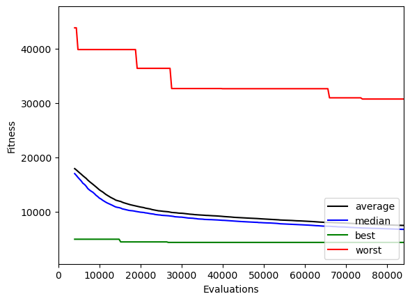

```python
import inspyred
import random

ea = inspyred.ec.emo.NSGA2(rng)
ea.variator = [inspyred.ec.variators.simulated_binary_crossover,
               inspyred.ec.variators.gaussian_mutation]
ea.replacer = inspyred.ec.replacers.crowding_replacement
ea.terminator = inspyred.ec.terminators.generation_termination
ea.observer = inspyred.ec.observers.plot_observer

R1 = 5
R2 = 5
R3 = 5
R4 = 5
R5 = 5

success_rate = []

final_pop = ea.evolve(generator=generate,
                      evaluator=function_with_dynamic_penalization_multiobjective,
                      pop_size=2000,
                      maximize=False,
                      bounder=inspyred.ec.Bounder([0, 1e-16, -0.55, -0.55], [1200, 1200, 0.55, 0.55]),
                      num_selected=200,
                      num_elites=1,
                      crossover_rate=1,
                      mutation_rate=0.05,
                      max_generations=200)

final_pop.sort(key=lambda x: x.fitness)
best = final_pop[0]
print(f'Best Solution: {str(best.candidate)}, Objective Value: {best.fitness}')
```

```python
function_to_minimize(best.candidate[0], best.candidate[1])
```

```
4138.335899158792
```

Se puede ver que la diferencia entre el valor real y el que tiene en cuenta los constraints es elevada, de aproximadamente 245.4866

### Resultados de los modelos y análisis estadístico

Se van a ejecutar los modelos anteriores varias veces, y se van a comparar los resultados que se obtienen con cada uno de ellos

Primero definimos las funciones que ejecutarán los modelos. Se devolverán los valores de fitness, penalty y tiempo de ejecucicón, para comparar estos tres factores

```python
def run_model_simple(seed, pop_size, crossover_rate, mutation_rate):

    start = time.time()

    global R1, R2, R3, R4, R5

    rng = random.Random()
    rng.seed(seed)
    ea = inspyred.ec.GA(rng)
    ea.selector = inspyred.ec.selectors.tournament_selection
    ea.variator = [inspyred.ec.variators.simulated_binary_crossover,
                  inspyred.ec.variators.gaussian_mutation]
    ea.replacer = inspyred.ec.replacers.generational_replacement
    ea.terminator = inspyred.ec.terminators.generation_termination

    R1 = 5
    R2 = 5
    R3 = 5
    R4 = 5
    R5 = 5

    final_pop = ea.evolve(generator=generate,
                          evaluator=function_with_dynamic_penalization,
                          pop_size=pop_size,
                          maximize=False,
                          bounder=inspyred.ec.Bounder([0, 1e-16, -0.55, -0.55], [1200, 1200, 0.55, 0.55]),
                          tournament_size=2,
                          max_generations=100,
                          crossover_rate=crossover_rate,
                          mutation_rate=mutation_rate,
                          num_elites=1)
    final_pop.sort(key=lambda x: x.fitness)

    penalty = abs(final_pop[0].fitness - function_to_minimize(final_pop[0].candidate[0], final_pop[0].candidate[1]))

    end = time.time()
    time_taken = (end-start)

    return final_pop[0], time_taken, penalty

def run_model_complex(seed, pop_size, crossover_rate, mutation_rate, selector, variator, replacer):

    start = time.time()

    global R1, R2, R3, R4, R5

    rng = random.Random()
    rng.seed(seed)
    ea = inspyred.ec.GA(rng)
    ea.selector = selector
    ea.variator = [variator,
                  inspyred.ec.variators.gaussian_mutation]
    ea.replacer = replacer
    ea.terminator = inspyred.ec.terminators.generation_termination

    R1 = 3
    R2 = 3
    R3 = 7
    R4 = 7
    R5 = 7

    final_pop = ea.evolve(generator=generate,
                          evaluator=function_with_dynamic_penalization,
                          pop_size=pop_size,
                          maximize=False,
                          bounder=inspyred.ec.Bounder([0, 1e-16, -0.55, -0.55], [1200, 1200, 0.55, 0.55]),
                          tournament_size=2,
                          max_generations=100,
                          crossover_rate=crossover_rate,
                          mutation_rate=mutation_rate,
                          num_elites=1)
    final_pop.sort(key=lambda x: x.fitness)

    penalty = abs(final_pop[0].fitness - function_to_minimize(final_pop[0].candidate[0], final_pop[0].candidate[1]))


    end = time.time()
    time_taken = (end-start)

    return final_pop[0], time_taken, penalty

def run_model_nsga2(seed, pop_size, crossover_rate, mutation_rate, variator, replacer):

    start = time.time()

    ea = inspyred.ec.emo.NSGA2(rng)
    ea.variator = [variator,
                  inspyred.ec.variators.gaussian_mutation]
    ea.replacer = replacer
    ea.terminator = inspyred.ec.terminators.generation_termination

    R1 = 5
    R2 = 5
    R3 = 5
    R4 = 5
    R5 = 5

    success_rate = []

    final_pop = ea.evolve(generator=generate,
                          evaluator=function_with_dynamic_penalization_multiobjective,
                          pop_size=pop_size,
                          maximize=False,
                          bounder=inspyred.ec.Bounder([0, 1e-16, -0.55, -0.55], [1200, 1200, 0.55, 0.55]),
                          num_selected=200,
                          num_elites=1,
                          crossover_rate=crossover_rate,
                          mutation_rate=mutation_rate,
                          max_generations=200)

    final_pop.sort(key=lambda x: x.fitness)

    penalty = abs(final_pop[0].fitness - function_to_minimize(final_pop[0].candidate[0], final_pop[0].candidate[1]))

    end = time.time()
    time_taken = (end-start)

    return final_pop[0], time_taken, penalty
```

Ejecución de los modelos

```python
results_1 = []
results_2 = []
results_3 = []
results_4 = []
results_5 = []
results_6 = []

time_taken_1 = []
time_taken_2 = []
time_taken_3 = []
time_taken_4 = []
time_taken_5 = []
time_taken_6 = []

penalties_1 = []
penalties_2 = []
penalties_3 = []
penalties_4 = []
penalties_5 = []
penalties_6 = []


seed = 123456789
for i in range(15):
    # 15 ejecuciones de las líneas de debajo:
    best_1, time_1, penalty_1 = run_model_simple(seed + i*71, 200, 1, 0.1)
    results_1.append(best_1.fitness)
    time_taken_1.append(time_1)
    penalties_1.append(penalty_1)

    best_2, time_2, penalty_2 = run_model_simple(seed + i*71, 146, 0.9624544382587448, 0.03141668139619255)
    results_2.append(best_2.fitness)
    time_taken_2.append(time_2)
    penalties_2.append(penalty_2)


    best_3, time_3, penalty_3 = run_model_complex(seed + i*71, 278, 0.8269764133047697, 0.11206562806068429, inspyred.ec.selectors.rank_selection, inspyred.ec.variators.blend_crossover, inspyred.ec.replacers.crowding_replacement)
    results_3.append(best_3.fitness)
    time_taken_3.append(time_3)
    penalties_3.append(penalty_3)

    best_4, time_4, penalty_4 = run_model_complex(seed + i*71, 150, 0.8251227150168696, 0.013113983719592503, inspyred.ec.selectors.rank_selection, inspyred.ec.variators.simulated_binary_crossover, inspyred.ec.replacers.crowding_replacement)
    results_4.append(best_4.fitness)
    time_taken_4.append(time_4)
    penalties_4.append(penalty_4)

    best_5, time_5, penalty_5 = run_model_complex(seed + i*71, 248, 0.9812965367772496, 0.16164682139638492, inspyred.ec.selectors.tournament_selection, inspyred.ec.variators.laplace_crossover, inspyred.ec.replacers.crowding_replacement)
    results_5.append(best_5.fitness)
    time_taken_5.append(time_5)
    penalties_5.append(penalty_5)

    best_6, time_6, penalty_6 = run_model_nsga2(seed + i*71, 2000, 1, 0.05, inspyred.ec.variators.simulated_binary_crossover, inspyred.ec.replacers.crowding_replacement)
    results_6.append(best_6.fitness)
    time_taken_6.append(time_6)
    penalties_6.append(penalty_6)
```

Cálculo de las medias y desviaciones estándar

```python
# Calcular la media y la desviación estándar
mean_1, std_1, time_mean_1, penalty_mean_1, penalty_std_1 = np.mean(results_1), np.std(results_1), np.mean(time_taken_1), np.mean(penalties_1), np.std(penalties_1)
mean_2, std_2, time_mean_2, penalty_mean_2, penalty_std_2 = np.mean(results_2), np.std(results_2), np.mean(time_taken_2), np.mean(penalties_2), np.std(penalties_2)
mean_3, std_3, time_mean_3, penalty_mean_3, penalty_std_3 = np.mean(results_3), np.std(results_3), np.mean(time_taken_3), np.mean(penalties_3), np.std(penalties_3)
mean_4, std_4, time_mean_4, penalty_mean_4, penalty_std_4 = np.mean(results_4), np.std(results_4), np.mean(time_taken_4), np.mean(penalties_4), np.std(penalties_4)
mean_5, std_5, time_mean_5, penalty_mean_5, penalty_std_5 = np.mean(results_5), np.std(results_5), np.mean(time_taken_5), np.mean(penalties_5), np.std(penalties_5)
mean_6, std_6, time_mean_6, penalty_mean_6, penalty_std_6 = np.mean(results_6), np.std(results_6), np.mean(time_taken_6), np.mean(penalties_6), np.std(penalties_6)

print(f"Model 1 ----> Fitness Mean = {mean_1}, Fitness Std = {std_1}, Time = {time_mean_1}, Penalty Mean = {penalty_mean_1}, Penalty Std = {penalty_std_1}")
print(f"Model 2 ----> Fitness Mean = {mean_2}, Fitness Std = {std_2}, Time = {time_mean_2}, Penalty Mean = {penalty_mean_2}, Penalty Std = {penalty_std_2}")
print(f"Model 3 ----> Fitness Mean = {mean_3}, Fitness Std = {std_3}, Time = {time_mean_3}, Penalty Mean = {penalty_mean_3}, Penalty Std = {penalty_std_3}")
print(f"Model 4 ----> Fitness Mean = {mean_4}, Fitness Std = {std_4}, Time = {time_mean_4}, Penalty Mean = {penalty_mean_4}, Penalty Std = {penalty_std_4}")
print(f"Model 5 ----> Fitness Mean = {mean_5}, Fitness Std = {std_5}, Time = {time_mean_5}, Penalty Mean = {penalty_mean_5}, Penalty Std = {penalty_std_5}")
print(f"Model 6 ----> Fitness Mean = {mean_6}, Fitness Std = {std_6}, Time = {time_mean_6}, Penalty Mean = {penalty_mean_6}, Penalty Std = {penalty_std_6}")
```

```
Model 1 ----> Fitness Mean = 4395.540201629069, Fitness Std = 226.51238492460172, Time = 0.5615448792775471, Penalty Mean = 35.50994019390334, Penalty Std = 53.65824941526392
Model 2 ----> Fitness Mean = 4428.398078371335, Fitness Std = 174.22158357089376, Time = 0.404157829284668, Penalty Mean = 112.33506594126341, Penalty Std = 246.50437182849174
Model 3 ----> Fitness Mean = 4346.099691883998, Fitness Std = 85.89215195157361, Time = 1.2896362940470378, Penalty Mean = 0.14163293295302234, Penalty Std = 0.2876502970210258
Model 4 ----> Fitness Mean = 4482.790565265402, Fitness Std = 334.0076304712891, Time = 0.5617019017537435, Penalty Mean = 126.10118369378482, Penalty Std = 242.5425349190477
Model 5 ----> Fitness Mean = 4192.707645741034, Fitness Std = 131.4008948603252, Time = 1.0377792358398437, Penalty Mean = 28.014828986009768, Penalty Std = 100.48960343976417
Model 6 ----> Fitness Mean = 7121.981345782335, Fitness Std = 893.1391535178317, Time = 3.5908588727315265, Penalty Mean = 2617.009368881549, Penalty Std = 841.9370750808706
```

Tests de Wilcoxon

```python
# Tests de Wilcoxon para el fitness y penalty
w, p = wilcoxon(results_1, results_2)
print(f"Fitness --- Wilcoxon signed-rank test for model1 vs model2: W = {w}, p-value = {p}")
w, p = wilcoxon(penalties_1, penalties_2)
print(f"Penalty --- Wilcoxon signed-rank test for model1 vs model2: W = {w}, p-value = {p}")

w, p = wilcoxon(results_1, results_3)
print(f"Fitness --- Wilcoxon signed-rank test for model1 vs model3: W = {w}, p-value = {p}")
w, p = wilcoxon(penalties_1, penalties_3)
print(f"Penalty --- signed-rank test for model1 vs model3: W = {w}, p-value = {p}")

w, p = wilcoxon(results_1, results_4)
print(f"Fitness --- Wilcoxon signed-rank test for model1 vs model4: W = {w}, p-value = {p}")
w, p = wilcoxon(penalties_1, penalties_4)
print(f"Penalty --- Wilcoxon signed-rank test for model1 vs model4: W = {w}, p-value = {p}")

w, p = wilcoxon(results_1, results_5)
print(f"Fitness --- Wilcoxon signed-rank test for model1 vs model5: W = {w}, p-value = {p}")
w, p = wilcoxon(penalties_1, penalties_5)
print(f"Penalty --- Wilcoxon signed-rank test for model1 vs model5: W = {w}, p-value = {p}")

w, p = wilcoxon(results_1, results_6)
print(f"Fitness --- Wilcoxon signed-rank test for model1 vs model6: W = {w}, p-value = {p}")
w, p = wilcoxon(penalties_1, penalties_6)
print(f"Penalty --- Wilcoxon signed-rank test for model1 vs model6: W = {w}, p-value = {p}")

w, p = wilcoxon(results_2, results_3)
print(f"Fitness --- Wilcoxon signed-rank test for model2 vs model3: W = {w}, p-value = {p}")
w, p = wilcoxon(penalties_2, penalties_3)
print(f"Penalty --- Wilcoxon signed-rank test for model2 vs model3: W = {w}, p-value = {p}")

w, p = wilcoxon(results_2, results_4)
print(f"Fitness --- Wilcoxon signed-rank test for model2 vs model4: W = {w}, p-value = {p}")
w, p = wilcoxon(penalties_2, penalties_4)
print(f"Penalty --- Wilcoxon signed-rank test for model2 vs model4: W = {w}, p-value = {p}")

w, p = wilcoxon(results_2, results_5)
print(f"Fitness --- Wilcoxon signed-rank test for model2 vs model5: W = {w}, p-value = {p}")
w, p = wilcoxon(penalties_2, penalties_5)
print(f"Penalty --- Wilcoxon signed-rank test for model2 vs model5: W = {w}, p-value = {p}")

w, p = wilcoxon(results_2, results_6)
print(f"Fitness --- Wilcoxon signed-rank test for model2 vs model6: W = {w}, p-value = {p}")
w, p = wilcoxon(penalties_2, penalties_6)
print(f"Penalty --- Wilcoxon signed-rank test for model2 vs model6: W = {w}, p-value = {p}")

w, p = wilcoxon(results_3, results_4)
print(f"Fitness --- Wilcoxon signed-rank test for model3 vs model4: W = {w}, p-value = {p}")
w, p = wilcoxon(penalties_3, penalties_4)
print(f"Penalty --- Wilcoxon signed-rank test for model3 vs model4: W = {w}, p-value = {p}")

w, p = wilcoxon(results_3, results_5)
print(f"Fitness --- Wilcoxon signed-rank test for model3 vs model5: W = {w}, p-value = {p}")
w, p = wilcoxon(penalties_3, penalties_5)
print(f"Penalty --- Wilcoxon signed-rank test for model3 vs model5: W = {w}, p-value = {p}")

w, p = wilcoxon(results_3, results_6)
print(f"Fitness --- Wilcoxon signed-rank test for model3 vs model6: W = {w}, p-value = {p}")
w, p = wilcoxon(penalties_3, penalties_6)
print(f"Penalty --- Wilcoxon signed-rank test for model3 vs model6: W = {w}, p-value = {p}")

w, p = wilcoxon(results_4, results_5)
print(f"Fitness --- Wilcoxon signed-rank test for model4 vs model5: W = {w}, p-value = {p}")
w, p = wilcoxon(penalties_4, penalties_5)
print(f"Penalty --- Wilcoxon signed-rank test for model4 vs model5: W = {w}, p-value = {p}")

w, p = wilcoxon(results_4, results_6)
print(f"Fitness --- Wilcoxon signed-rank test for model4 vs model6: W = {w}, p-value = {p}")
w, p = wilcoxon(penalties_4, penalties_6)
print(f"Penalty --- Wilcoxon signed-rank test for model4 vs model6: W = {w}, p-value = {p}")

w, p = wilcoxon(results_5, results_6)
print(f"Fitness --- Wilcoxon signed-rank test for model5 vs model6: W = {w}, p-value = {p}")
w, p = wilcoxon(penalties_5, penalties_6)
print(f"Penalty --- Wilcoxon signed-rank test for model5 vs model6: W = {w}, p-value = {p}")
```

```
Fitness --- Wilcoxon signed-rank test for model1 vs model2: W = 48.0, p-value = 0.52447509765625
Penalty --- Wilcoxon signed-rank test for model1 vs model2: W = 56.0, p-value = 0.846923828125
Fitness --- Wilcoxon signed-rank test for model1 vs model3: W = 56.0, p-value = 0.846923828125
Penalty --- signed-rank test for model1 vs model3: W = 5.0, p-value = 0.0006103515625
Fitness --- Wilcoxon signed-rank test for model1 vs model4: W = 43.0, p-value = 0.359130859375
Penalty --- Wilcoxon signed-rank test for model1 vs model4: W = 53.0, p-value = 0.7197265625
Fitness --- Wilcoxon signed-rank test for model1 vs model5: W = 8.0, p-value = 0.00152587890625
Penalty --- Wilcoxon signed-rank test for model1 vs model5: W = 28.0, p-value = 0.072998046875
Fitness --- Wilcoxon signed-rank test for model1 vs model6: W = 0.0, p-value = 6.103515625e-05
Penalty --- Wilcoxon signed-rank test for model1 vs model6: W = 0.0, p-value = 6.103515625e-05
Fitness --- Wilcoxon signed-rank test for model2 vs model3: W = 37.0, p-value = 0.207763671875
Penalty --- Wilcoxon signed-rank test for model2 vs model3: W = 14.0, p-value = 0.0067138671875
Fitness --- Wilcoxon signed-rank test for model2 vs model4: W = 49.0, p-value = 0.5614013671875
Penalty --- Wilcoxon signed-rank test for model2 vs model4: W = 50.0, p-value = 0.5994873046875
Fitness --- Wilcoxon signed-rank test for model2 vs model5: W = 0.0, p-value = 6.103515625e-05
Penalty --- Wilcoxon signed-rank test for model2 vs model5: W = 44.0, p-value = 0.389404296875
Fitness --- Wilcoxon signed-rank test for model2 vs model6: W = 0.0, p-value = 6.103515625e-05
Penalty --- Wilcoxon signed-rank test for model2 vs model6: W = 0.0, p-value = 6.103515625e-05
Fitness --- Wilcoxon signed-rank test for model3 vs model4: W = 44.0, p-value = 0.389404296875
Penalty --- Wilcoxon signed-rank test for model3 vs model4: W = 15.0, p-value = 0.00836181640625
Fitness --- Wilcoxon signed-rank test for model3 vs model5: W = 16.0, p-value = 0.01025390625
Penalty --- Wilcoxon signed-rank test for model3 vs model5: W = 3.0, p-value = 0.00030517578125
Fitness --- Wilcoxon signed-rank test for model3 vs model6: W = 0.0, p-value = 6.103515625e-05
Penalty --- Wilcoxon signed-rank test for model3 vs model6: W = 0.0, p-value = 6.103515625e-05
Fitness --- Wilcoxon signed-rank test for model4 vs model5: W = 9.0, p-value = 0.00201416015625
Penalty --- Wilcoxon signed-rank test for model4 vs model5: W = 40.0, p-value = 0.27685546875
Fitness --- Wilcoxon signed-rank test for model4 vs model6: W = 0.0, p-value = 6.103515625e-05
Penalty --- Wilcoxon signed-rank test for model4 vs model6: W = 0.0, p-value = 6.103515625e-05
Fitness --- Wilcoxon signed-rank test for model5 vs model6: W = 0.0, p-value = 6.103515625e-05
Penalty --- Wilcoxon signed-rank test for model5 vs model6: W = 0.0, p-value = 6.103515625e-05
```

Viendo estos resultados, podemos concluir que los modelos 1, 2, 3 y 4 no son diferenciables según el test de Wilcoxon (fitness). Los modelos 5 y 6 sí son, tanto diferentes con el resto, como diferentes entre sí

Si sólo tenemos en cuenta la fitness, parece que el modelo 5 es el mejor, puesto que, de media, es el que más logra minimizar la función

Sin embargo, si tenemos en cuenta también los constraints, pese a que los modelos 1, 2, 3 y 4 según Wilcoxon, no se distinguen en la fitness, sí se puede apreciar que el modelo 3 lográ cumplir bastante bien las restricciones. Además, el test de Wilcoxon (penalty) nos confirma que sí hay una diferencia significativa en las penalizaciones del modelo 3 frente a los modelos 1, 2 y 4

En cuanto al tiempo de ejecución, el modelo 2 es el más rápido, y el modelo 6 (NSGA-II) es el más lento con diferencia y con peores resultados

Teniendo todo esto en cuenta, yo escogería el modelo 3, puesto que, a pesar de minimizar menos que el modelo 5, y ser algo más lento en ejecución, logra ajustar las soluciones bastante bien a los constraints

### Tabla de datos

Se va a hacer un daatframe con los resultados obtenidos con el objetivo de tener una visualización rápida de éstos en forma de tabla

```python
df = pd.DataFrame()

df['Model_Type'] = ['Base Model', 'Base Model with Optuna', 'Model with Optuna', 'Model with Optuna', 'Model with Optuna', 'Model NSGA-II']
df['Fitness_Avg'] = [mean_1, mean_2, mean_3, mean_4, mean_5, mean_6]
df['Fitness_Std'] = [std_1, std_2, std_3, std_4, std_5, std_6]
df['Penalty_Avg'] = [penalty_mean_1, penalty_mean_2, penalty_mean_3, penalty_mean_4, penalty_mean_5, penalty_mean_6]
df['Penalty_Std'] = [penalty_std_1, penalty_std_2, penalty_std_3, penalty_std_4, penalty_std_5, penalty_std_6]
df['Time_Avg'] = [time_mean_1, time_mean_2, time_mean_3, time_mean_4, time_mean_5, time_mean_6]
df['Pop_Size'] = [200, 146, 278, 150, 248, 2000]
df['Crossover_Rate'] = [1, 0.9624544382587448, 0.8269764133047697,  0.8251227150168696, 0.9812965367772496, 1]
df['Mutation_Rate'] = [0.1, 0.03141668139619255, 0.11206562806068429, 0.013113983719592503, 0.16164682139638492, 0.05]
df['Selectors'] = ['Tournament Selection', 'Tournament Selection', 'Rank Selection', 'Rank Selection', 'Tournament Selection', 'NSGA-II Default Selection']
df['Variators'] = ['Simulated Binary Crossover', 'Simulated Binary Crossover', 'Blend Crossover', 'Simulated Binary Crossover', 'Laplace Crossover', 'Simulated Binary Crossover']
df['Replacers'] = ['Generational Replacement', 'Generational Replacement', 'Crowding Replacement', 'Crowding Replacement', 'Crowding Replacement', 'Crowding Replacement']
```

```python
df
```

|  | Model_Type | Fitness_Avg | Fitness_Std | Penalty_Avg | Penalty_Std | Time_Avg | Pop_Size | Crossover_Rate | Mutation_Rate | Selectors | Variators | Replacers |
| --- | --- | --- | --- | --- | --- | --- | --- | --- | --- | --- | --- | --- |
| 0 | Base Model | 4395.540202 | 226.512385 | 35.509940 | 53.658249 | 0.561545 | 200 | 1.000000 | 0.100000 | Tournament Selection | Simulated Binary Crossover | Generational Replacement |
| 1 | Base Model with Optuna | 4428.398078 | 174.221584 | 112.335066 | 246.504372 | 0.404158 | 146 | 0.962454 | 0.031417 | Tournament Selection | Simulated Binary Crossover | Generational Replacement |
| 2 | Model with Optuna | 4346.099692 | 85.892152 | 0.141633 | 0.287650 | 1.289636 | 278 | 0.826976 | 0.112066 | Rank Selection | Blend Crossover | Crowding Replacement |
| 3 | Model with Optuna | 4482.790565 | 334.007630 | 126.101184 | 242.542535 | 0.561702 | 150 | 0.825123 | 0.013114 | Rank Selection | Simulated Binary Crossover | Crowding Replacement |
| 4 | Model with Optuna | 4192.707646 | 131.400895 | 28.014829 | 100.489603 | 1.037779 | 248 | 0.981297 | 0.161647 | Tournament Selection | Laplace Crossover | Crowding Replacement |
| 5 | Model NSGA-II | 7121.981346 | 893.139154 | 2617.009369 | 841.937075 | 3.590859 | 2000 | 1.000000 | 0.050000 | NSGA-II Default Selection | Simulated Binary Crossover | Crowding Replacement |

### Gráficos

```python
def run_model_simple_with_plots(seed, pop_size, crossover_rate, mutation_rate):

    global R1, R2, R3, R4, R5

    rng = random.Random()
    rng.seed(seed)
    ea = inspyred.ec.GA(rng)
    ea.selector = inspyred.ec.selectors.tournament_selection
    ea.variator = [inspyred.ec.variators.simulated_binary_crossover,
                  inspyred.ec.variators.gaussian_mutation]
    ea.replacer = inspyred.ec.replacers.generational_replacement
    ea.terminator = inspyred.ec.terminators.generation_termination
    ea.observer = [inspyred.ec.observers.plot_observer, inspyred.ec.observers.file_observer]

    R1 = 5
    R2 = 5
    R3 = 5
    R4 = 5
    R5 = 5

    final_pop = ea.evolve(generator=generate,
                          evaluator=function_with_dynamic_penalization,
                          pop_size=pop_size,
                          maximize=False,
                          bounder=inspyred.ec.Bounder([0, 1e-16, -0.55, -0.55], [1200, 1200, 0.55, 0.55]),
                          tournament_size=2,
                          max_generations=100,
                          crossover_rate=crossover_rate,
                          mutation_rate=mutation_rate,
                          num_elites=1)
    final_pop.sort(key=lambda x: x.fitness)

    return final_pop[0]

def run_model_complex_with_plots(seed, pop_size, crossover_rate, mutation_rate, selector, variator, replacer):

    global R1, R2, R3, R4, R5

    rng = random.Random()
    rng.seed(seed)
    ea = inspyred.ec.GA(rng)
    ea.selector = selector
    ea.variator = [variator,
                  inspyred.ec.variators.gaussian_mutation]
    ea.replacer = replacer
    ea.terminator = inspyred.ec.terminators.generation_termination
    ea.observer = [inspyred.ec.observers.plot_observer, inspyred.ec.observers.file_observer]

    R1 = 3
    R2 = 3
    R3 = 7
    R4 = 7
    R5 = 7

    final_pop = ea.evolve(generator=generate,
                          evaluator=function_with_dynamic_penalization,
                          pop_size=pop_size,
                          maximize=False,
                          bounder=inspyred.ec.Bounder([0, 1e-16, -0.55, -0.55], [1200, 1200, 0.55, 0.55]),
                          tournament_size=2,
                          max_generations=100,
                          crossover_rate=crossover_rate,
                          mutation_rate=mutation_rate,
                          num_elites=1)
    final_pop.sort(key=lambda x: x.fitness)

    return final_pop[0]

def run_model_nsga2_with_plots(seed, pop_size, crossover_rate, mutation_rate, variator, replacer):

    ea = inspyred.ec.emo.NSGA2(rng)
    ea.variator = [variator,
                  inspyred.ec.variators.gaussian_mutation]
    ea.replacer = replacer
    ea.terminator = inspyred.ec.terminators.generation_termination
    ea.observer = [inspyred.ec.observers.plot_observer, inspyred.ec.observers.file_observer]

    R1 = 5
    R2 = 5
    R3 = 5
    R4 = 5
    R5 = 5

    success_rate = []

    final_pop = ea.evolve(generator=generate,
                          evaluator=function_with_dynamic_penalization_multiobjective,
                          pop_size=pop_size,
                          maximize=False,
                          bounder=inspyred.ec.Bounder([0, 1e-16, -0.55, -0.55], [1200, 1200, 0.55, 0.55]),
                          num_selected=200,
                          num_elites=1,
                          crossover_rate=crossover_rate,
                          mutation_rate=mutation_rate,
                          max_generations=200)

    final_pop.sort(key=lambda x: x.fitness)

    return final_pop[0]
```

Es necesario modificar la función de "allele_plot" que incluye inspyred, puesto que utiliza una versión de arrays deprecada (plt arrays). Se han cambiado estos arrays por arrays de numpy (np arrays)

Se debe tener en cuenta también que esta función guarda los archivos con un nombre que contiene la hora, minutos y segundos de cuando se ha creado ese fichero

```python
def allele_plot(file, normalize=False, alleles=None, generations=None):
    """Plot the alleles from each generation from the individuals file.

    This function creates a plot of the individual allele values as they
    change through the generations. It creates three subplots, one for each
    of the best, median, and average individual. The best and median
    individuals are chosen using the fitness data for each generation. The
    average individual, on the other hand, is actually an individual created
    by averaging the alleles within a generation. This function requires the
    matplotlib library.

    .. note::

       This function only works for single-objective problems.

    .. figure:: _static/allele_plot.png
        :alt: Example allele plot
        :align: center

        An example image saved from the ``allele_plot`` function.

    Arguments:

    - *file* -- a file-like object representing the individuals file
      produced by the file_observer
    - *normalize* -- Boolean value stating whether allele values should be
      normalized before plotting (default False)
    - *alleles* -- a list of allele index values that should be plotted
      (default None)
    - *generations* -- a list of generation numbers that should be plotted
      (default None)

    If *alleles* is ``None``, then all alleles are plotted. Similarly, if
    *generations* is ``None``, then all generations are plotted.

    """
    import matplotlib.pyplot as plt

    generation_data = []
    reader = csv.reader(open(file))
    for row in reader:
        g = int(row[0])
        row[3] = row[3].replace('[', '')
        row[-1] = row[-1].replace(']', '')
        individual = [float(r) for r in row[3:]]
        individual.append(float(row[2]))
        try:
            generation_data[g]
        except IndexError:
            generation_data.append([])
        generation_data[g].append(individual)
    for gen in generation_data:
        gen.sort(key=lambda x: x[-1])
        for j, g in enumerate(gen):
            gen[j] = g[:-1]

    best = []
    median = []
    average = []
    for gen in generation_data:
        best.append(gen[0])
        plen = len(gen)
        if plen % 2 == 1:
            med = gen[(plen - 1) // 2]
        else:
            med = []
            for a, b in zip(gen[plen // 2 - 1], gen[plen // 2]):
                med.append(float(a + b) / 2)
        median.append(med)
        avg = [0] * len(gen[0])
        for individual in gen:
            for i, allele in enumerate(individual):
                avg[i] += allele
        for i, a in enumerate(avg):
            avg[i] /= float(len(gen))
        average.append(avg)

    for plot_num, (data, title) in enumerate(zip([best, median, average],
                                                 ["Best", "Median", "Average"])):
        if alleles is None:
            alleles = list(range(len(data[0])))
        if generations is None:
            generations = list(range(len(data)))
        if normalize:
            columns = list(zip(*data))
            max_col = [max(c) for c in columns]
            min_col = [min(c) for c in columns]
            for dat in data:
                for i, d in enumerate(dat):
                    dat[i] = (d - min_col[i]) / float(max_col[i] - min_col[i])
        plot_data = []
        for g in generations:
            plot_data.append([data[g][a] for a in alleles])
        sub = plt.subplot(3, 1, plot_num + 1)
        plt.pcolor(np.array(plot_data))
        plt.colorbar()
        step_size = max(len(generations) // 7, 1)
        ytick_locs = list(range(step_size, len(generations), step_size))
        ytick_labs = generations[step_size::step_size]
        plt.yticks(ytick_locs, ytick_labs)
        plt.ylabel('Generation')
        if plot_num == 2:
            xtick_locs = list(range(len(alleles)))
            xtick_labs = alleles
            plt.xticks(xtick_locs, xtick_labs)
            plt.xlabel('Allele')
        else:
            plt.setp(sub.get_xticklabels(), visible=False)
        plt.title(title)
    plt.show()
```

### Gráficos del modelo 1

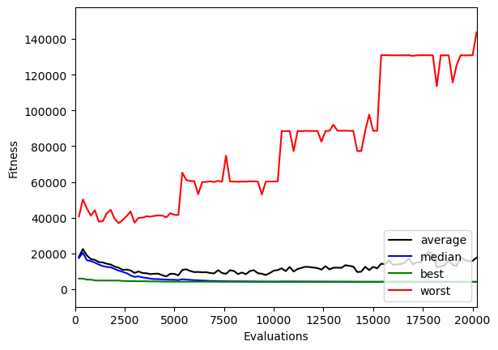

```python
to_plot_1 = run_model_simple_with_plots(33, 200, 1, 0.1)
```

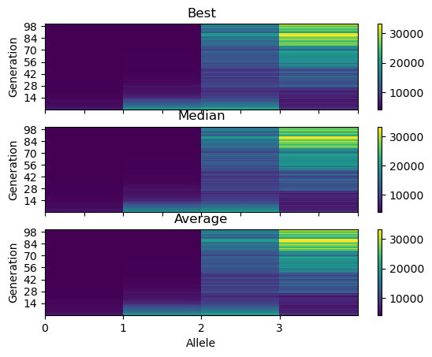

```python
allele_plot('content/inspyred-statistics-file-12032023-161157.csv', normalize = False)
```

### Gráficos del modelo 2

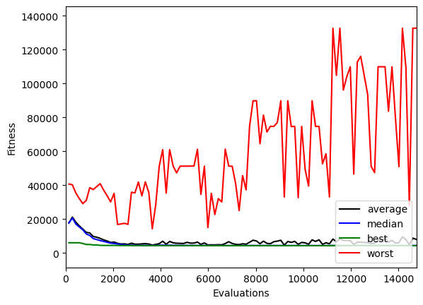

```python
to_plot_2 = run_model_simple_with_plots(33, 146, 0.9624544382587448, 0.03141668139619255)
```

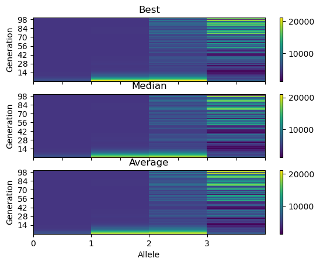

```python
allele_plot('content/inspyred-statistics-file-12032023-161254.csv', normalize = False)
```

### Gráficos del modelo 3

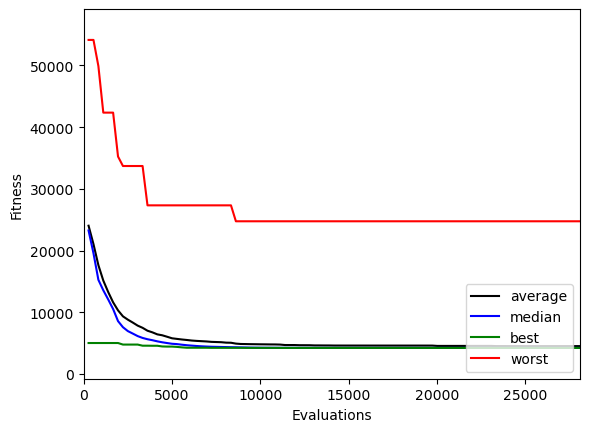

```python
to_plot_3 = run_model_complex_with_plots(33, 278, 0.8269764133047697, 0.11206562806068429, inspyred.ec.selectors.rank_selection, inspyred.ec.variators.blend_crossover, inspyred.ec.replacers.crowding_replacement)
```

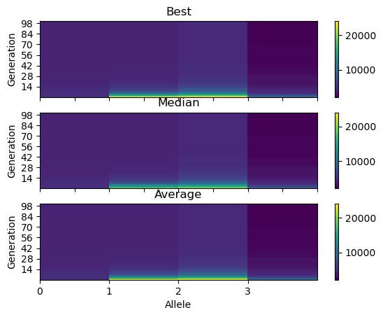

```python
allele_plot('content/inspyred-statistics-file-12032023-161337.csv', normalize = False)
```

### Gráficos del modelo 4

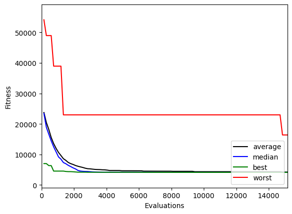

```python
to_plot_4 = run_model_complex_with_plots(33, 150, 0.8251227150168696, 0.013113983719592503, inspyred.ec.selectors.rank_selection, inspyred.ec.variators.simulated_binary_crossover, inspyred.ec.replacers.crowding_replacement)
```

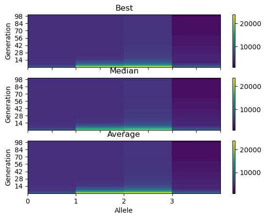

```python
allele_plot('content/inspyred-statistics-file-12032023-161420.csv', normalize = False)
```

### Gráficos del modelo 5

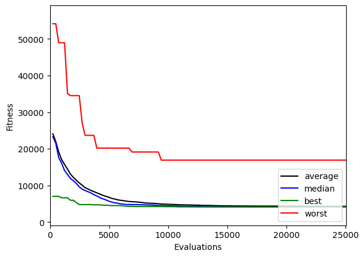

```python
to_plot_5 = run_model_complex_with_plots(33, 248, 0.9812965367772496, 0.16164682139638492, inspyred.ec.selectors.tournament_selection, inspyred.ec.variators.laplace_crossover, inspyred.ec.replacers.crowding_replacement)
```

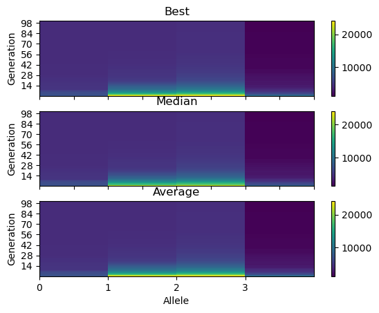

```python
allele_plot('content/inspyred-statistics-file-12032023-161454.csv', normalize = False)
```

### Gráficos del modelo 6

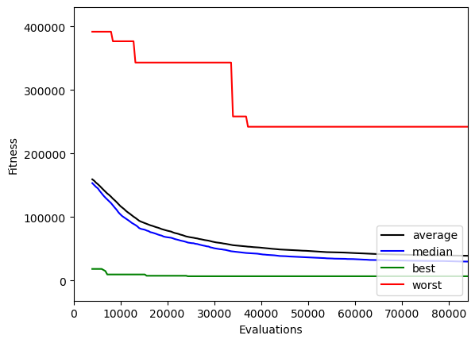

```python
to_plot_6 = run_model_nsga2_with_plots(33, 2000, 1, 0.05, inspyred.ec.variators.simulated_binary_crossover, inspyred.ec.replacers.crowding_replacement)
```

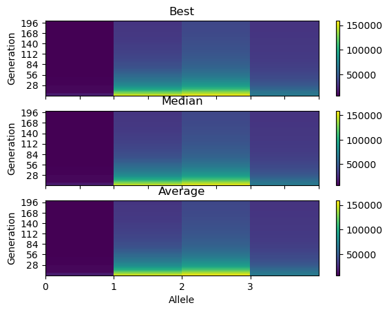

```python
allele_plot('content/inspyred-statistics-file-12032023-161520.csv', normalize = False)
```